# Assignment 4

**CS2831 Computer Vision, Harvard University, Fall 2026**

**Due Wednesday, Oct. 7, at 10:00 pm**

Name One: *(Radhika Saran)*  
Name Two: *(Joshua Blair)*

This assignment reinforces your understanding of structure-from-motion, both batch algorithms (factorization) and sequential algorithms. As usual, the assignment will be submitted electronically and formatted according to the guidelines.

Unlike previous assignments, this assignment is **meant to be completed in pairs**. You and your teammate will collaborate in the design and implementation of your solution in a single colab notebook. At submission time, each teammate will submit a copy of the notebook to Gradescope, along with their own supplemental PDF that includes a one-paragraph description of their own contributions and their teammate's contributions.

If you have not already done so, identify a teammate, and then begin by creating a copy of this notebook in your google drive at filepath `My Drive/cs-283-assignments/A4/pset4.ipynb`. Then edit the notebook and submit it according to the instructions on the course website.

#### Important Notes

- Question 2 is longer than Question 1, and it takes the form of an open-ended design problem. In Question 2, you and your teammate are tasked with designing and implementing a sequential structure-from-motion pipeline. Your goal is to create an accurate reconstruction of 3D points and cameras using as many images as possible from a particular 24-image sequence, and to also create a visualization of your reconstruction.
- Unlike previous assignments, where you were asked to code many of your functions from scratch, we expect that your solution to Question 2 will make substantial use of the structure-from-motion functions that are already built in to the OpenCV library. This includes functions for: feature detection and matching; estimating fundamental and essential matrices (with RANSAC); factoring an essential matrix into a rotation and translation; triangulation; and solving the perspective-n-point problem.
- Due to technical limitations, your plotly figures will not be included when you export your `.ipynb` notebook to `.html` (and the PDF) for submission. That's OK, and it is handled in two ways. For Question 1, the instructions require that you make plots in both plotly and matplotlib, so that the latter is included in your PDF submission. For Question 2, the instructions require that you export your interactive plotly figure to a standalone HTML file and upload that to Canvas.

## Setup

```python
#@title mount google drive
# On Colab this mounts your Google Drive.  Running anywhere else -- a local
# Jupyter install, for instance -- it is skipped, and the notebook works in the
# current directory instead.
try:
    from google.colab import drive
    drive.mount('/content/drive')
    IN_COLAB = True
except ImportError:
    IN_COLAB = False
    print("not running on Colab -- using the current directory")
```

```python
#@title set working directory
import os

if IN_COLAB:
    WORKDIR = "/content/drive/My Drive/cs-283-assignments/A4"
    os.makedirs(WORKDIR, exist_ok=True)
    os.chdir(WORKDIR)

WORKDIR = os.getcwd()
print("working directory:", WORKDIR)

if not os.path.exists("pset4.ipynb"):
    print("\nWARNING: pset4.ipynb was not found in this folder.\n"
          "Save your copy of the notebook to\n"
          f"    {WORKDIR}/pset4.ipynb\n"
          "before you submit, or the submission cells at the end will fail.")
```

```
working directory: /content/drive/My Drive/cs-283-assignments/A4
```

```python
#@title fetch required files
import os

# Every file the notebook can open.  Listing all of them, rather than a
# sample, is what makes this guard catch a partial extraction: add_camera()
# reads playroom_<i>.png for any i in 1..24, and a missing one would otherwise
# slip through here and just quietly shrink your reconstruction later.
# (playroom_colmap_480p.mov is in the data folder too, but nothing reads it.)
REQUIRED = (["corners.pickle", "M7Slide.png"]
            + [f"scene_{i:02d}.png" for i in range(1, 20)]
            + [f"playroom_{i:05d}.png" for i in range(1, 25)])

missing = [f for f in REQUIRED if not os.path.exists("data/" + f)]
if missing:
    print("downloading:", ", ".join(missing))
    !curl -fsSL https://codeload.github.com/Harvard-CS283/pset-data/tar.gz/main | \
        tar -xz --strip=2 pset-data-main/pset4/data
else:
    print("data already present in", os.path.join(os.getcwd(), "data"))

still_missing = [f for f in REQUIRED if not os.path.exists("data/" + f)]
assert not still_missing, f"download failed, missing: {still_missing}"
```

```
data already present in /content/drive/My Drive/cs-283-assignments/A4/data
```

```python
#@title import libraries
import cv2                      # OpenCV
import numpy as np              # numpy
import pickle
import torch                    # used for the optimisation in Question 1c
import torch.optim as optim

import matplotlib.pyplot as plt
plt.rcParams['figure.figsize'] = [10, 10]

import plotly.graph_objs as go  # interactive 3D plots

print("OpenCV", cv2.__version__, "| numpy", np.__version__, "| torch", torch.__version__)
```

```
OpenCV 5.0.0 | numpy 2.1.3 | torch 2.11.0+cpu
```

```python
#@title utility functions
def plot_3d(X):
    """Static matplotlib scatter of an n x 3 array of world points.

    This is the one that ends up in your PDF, so it is the one we grade."""
    fig = plt.figure(figsize=(7, 7))
    ax = plt.axes(projection='3d')
    ax.scatter(X[:, 0], X[:, 1], X[:, 2], s=8)
    ax.set_xlabel('x'); ax.set_ylabel('y'); ax.set_zlabel('z')
    plt.show()


def plot_interactive_3d(X):
    """Interactive plotly scatter of an n x 3 array of world points.

    Plotly figures do not survive the export to HTML/PDF, so this one is for
    you to inspect the reconstruction while you work."""
    fig = go.Figure(go.Scatter3d(
        x=X[:, 0], y=X[:, 1], z=X[:, 2],
        mode='markers', marker=dict(size=2)))
    fig.update_layout(scene=dict(xaxis_title='x', yaxis_title='y',
                                 zaxis_title='z', aspectmode='data'),
                      scene_dragmode='orbit')
    fig.show()


def add_plotly_camera(h, w, camera, raysize, figobj):
    """Add a tetrahedral camera to a plotly figure.

    Parameters:
        h (int): Height of the image in pixels
        w (int): Width of the image in pixels
        camera (numpy.ndarray): 3x4 camera matrix
        raysize (float): Length of camera's tetrahedral edges (in world units)
        figobj (plotly.graph_objs.Figure): plotly figure object

    Returns:
        int: 1

    Note: Uses anatomy of camera matrices from Hartley and Zisserman Chapter 6
    """
    # normalize camera such that bottom-left three-vector
    #   corresponds to unit-length principal ray in front of camera (HZ Section 6.2.3)
    camera = camera*np.sign(np.linalg.det(camera[:, 0:3]))/np.linalg.norm(camera[2, 0:3])

    # Compute camera center (null vector of P)
    _, _, v = np.linalg.svd(camera)
    C = np.transpose(v[-1, 0:3]) / v[-1, 3]

    # Back-project image corners to unit-length 3D ray segments:
    S = np.array([[0, 0, 1],       # homog image coords if top left pixel
                  [0, h-1, 1],     # bottom left
                  [w-1, h-1, 1],   # bottom right
                  [w, 0, 1]])      # top right

    #   HZ equation (6.14): compute one 3D point along each ray
    X = np.transpose(np.linalg.lstsq(
        camera[:, 0:3],
        np.transpose(S)-np.expand_dims(camera[:, 3], axis=1),
        rcond=None)[0])

    #   unit-vectors from camera center to each 3D point
    V = X - np.tile(C, (4, 1))
    V = V / np.linalg.norm(V, ord=2, axis=1, keepdims=True)

    # make sure these vectors point forwards from the camera instead of backwards
    V = V*np.expand_dims(np.sign(np.sum(V * np.tile(camera[2, 0:3], (4, 1)), axis=1)), axis=1)

    #   desired ray segments that are length raysize in these directions
    V = np.tile(C, (4, 1)) + raysize * V

    # append the camera center itself to complete the four tetrahedral vertices
    V = np.vstack([C, V])

    figobj.add_trace(go.Scatter3d(
        x=[C[0]], y=[C[1]], z=[C[2]],
        mode='markers', marker=dict(size=3, color='#ff7f0e')))

    figobj.add_trace(go.Mesh3d(
        x=V[:, 0], y=V[:, 1], z=V[:, 2],
        i=[0, 0, 0, 0], j=[1, 2, 3, 4], k=[2, 3, 4, 1],
        opacity=0.5, color='#ff7f0e'))

    return 1


def make_visualization(camera_dic, h, w, filename="reconstruction.html"):
    """Plot every reconstructed point and camera in `camera_dic`, and also
    write the figure to a standalone HTML file (see Question 2b).

    Expects keys of the form '3d_comple_<i>' (n x 3 point arrays) and
    'P_<i>' (3 x 4 camera matrices)."""
    pts_3d_total = np.empty((0, 3))
    for key in camera_dic:
        if '3d_comple_' in key:
            pts_3d_total = np.concatenate((pts_3d_total, camera_dic[key]), axis=0)

    fig = go.Figure()
    fig.add_trace(go.Scatter3d(
        x=pts_3d_total[:, 0], y=pts_3d_total[:, 1], z=pts_3d_total[:, 2],
        mode='markers', marker=dict(size=1)))

    for key in camera_dic:
        if key.startswith('P_'):
            add_plotly_camera(h, w, camera_dic[key], 1, fig)

    fig.update_traces(showlegend=False)
    fig.update_layout(scene_dragmode='orbit', scene=dict(aspectmode='data'))
    # include_plotlyjs='cdn' keeps the file small (a few hundred KB instead of
    # ~5 MB) by loading plotly.js from the web rather than inlining it.  The file
    # therefore needs an internet connection to open.
    fig.write_html(filename, include_plotlyjs='cdn')
    # Show the figure here rather than returning it: returning it as well would
    # make Jupyter display the cell's value on top of this, giving two copies.
    fig.show()
```

# Question 1 (40%)

The assignment's data folder contains m=19 parallel-projection images of a scene (`scene_##.png`). It also contains a `.pickle` file with the pixel coordinates of $n=78$ corners detected in each image as an $n\times 2\times m$ array named `corners`. (For example, `corners[j,:,i]` gives the $(x,y)$-coordinates of $\tilde{\bf x}_j^i$, the $j^{th}$ point in the $i^{th}$ image.)

## 1a. Recover the cameras and world points by factorization

Use the factorization algorithm to recover the nineteen affine cameras and world points from these pixel coordinates. Write a function `affine_factorization(x)` that takes an $n\times 2\times m$ array of pixel coordinates, corresponding to $n$ world points observed in $m$ views, and returns $2m\times3$ and $2m\times 1$ matrices `M` and `T` that describe the $m$ affine cameras, and an $n\times 3$ matrix `X` with the coordinates of the $n$ world points.

Plot the recovered points twice: once using plotly via `plot_interactive_3d` and again using matplotlib via `plot_3d`.

*Note on row order: it is up to you how to order the $2m$ rows of `M` and `T`, but be consistent, and remember what you chose -- you will need it again in part **c**, where the two rows belonging to a single camera have to be paired up correctly.*

```
Corners shape:  (78, 2, 19)
```

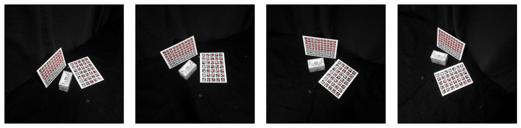

```python
## Load the corners
with open("data/corners.pickle", "rb") as f:
    variables = pickle.load(f)
    corners = variables['img_points']
print("Corners shape: ", corners.shape)

## Visualize some of the images
fig, ax = plt.subplots(1, 4, figsize=(3*4, 3))
for i in range(4):
    filename = f"data/scene_{(i+1):02d}.png"
    orig = cv2.imread(filename)
    img = cv2.cvtColor(orig, cv2.COLOR_BGR2GRAY)

    ax[i].imshow(img, cmap="gray")
    ax[i].scatter(corners[:, 0, i], corners[:, 1, i], marker='o', s=1, color='#d62728')
    ax[i].axis('off')
plt.tight_layout()
```

```
M: (38, 3)  T: (38, 1)  X: (78, 3)
```

[interactive chart not shown]

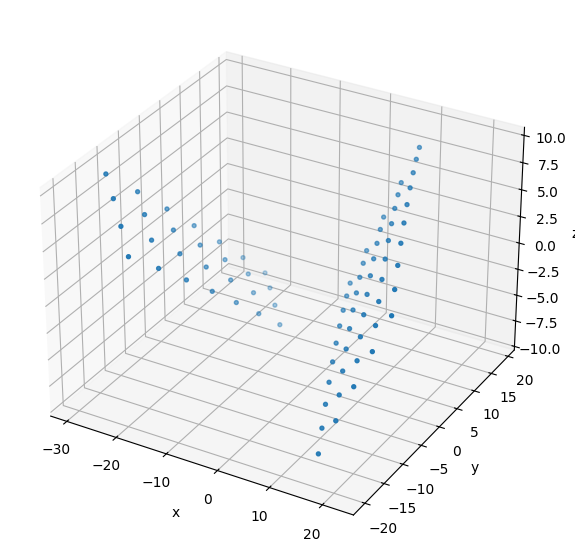

```python
def affine_factorization(x):
    """
    input:
        x: an n x 2 x m array denoting the detected corners in each image
    output:
        M: 2m x 3 matrix describing the m affine cameras
        T: 2m x 1 matrix of camera translations
        X: n x 3 matrix with the coordinates of the n world points
    """
    n, two, m = x.shape
    assert two == 2 # Expected x to have shape (n x 2 x m)

    W = np.zeros((2*m, n)) # 3D Measurement matrix converted into a 2D matrix
    T = np.zeros(2*m) # translation

    # Loop through all images
    for i in range(m):
      u = x[:, 0, i] # all x coords
      v = x[:, 1, i] # all y coords

      T[2 * i] = np.mean(u) # mean x pixel location
      T[2 * i + 1] = np.mean(v) # mean y pixel location

      # center each image
      W[2 * i, :] = u - T[2 * i]
      W[2 * i + 1, :] = v - T[2 * i + 1]

    # SVD
    U, S, Vt = np.linalg.svd(W, full_matrices=False) # SVD of W

    # Discard the dimensions beyond the first three
    U3 = U[:, :3]
    S3 = np.diag(S[:3]) # 3x3 diagonal scalar
    Vt3 = Vt[:3, :]

    S3_sqrt = np.sqrt(S3)

    M = U3 @ S3_sqrt
    X = (S3_sqrt @ Vt3).T

    return M, T.reshape(-1, 1), X


M, T, X = affine_factorization(corners)
print("M:", M.shape, " T:", T.shape, " X:", X.shape)
plot_interactive_3d(X)
plot_3d(X)
```

## 1b. Reprojection error

One measure of the accuracy of the reconstruction is the root-mean-square (RMS) reprojection error

$ E_{rms}=\left(\frac{1}{nm}\sum_{ij} ||\tilde{\bf x}_j^i - ({\bf M}^i{\bf X}_j+{\bf t}^i)||^2\right)^{1/2} $

Compute and report the RMS reprojection error for your reconstruction.

```python
def calc_RMS(corners, M, X, T):
    """RMS reprojection error, in pixels, of the reconstruction (M, T, X)."""
    n, _, m = corners.shape

    tot_sqr_err = 0

    for i in range(m):
      M_i = M[2*i : 2*i+2, :] # get this image's camera
      t_i = T[2*i : 2*i+2, :] # get this image's translation

      predicted = (M_i @ X.T + t_i).T # project the 3D points into the image
      observed = corners[:, :, i] # current positions
      residual = observed - predicted # residual error between actual and predicted

      tot_sqr_err += np.sum(residual**2) # add all errors

    Erms = np.sqrt(tot_sqr_err / (n * m)) # error root mean square

    return Erms


print("E_rms = {:.4f} pixels".format(calc_RMS(corners, M, X, T))) # start crying if its high
```

```
E_rms = 11.8408 pixels
```

## 1c. Upgrade to a metric reconstruction

Upgrade the reconstruction by enforcing constraints corresponding to 'square pixels and zero skew'. Do this by writing a simple function that evaluates the objective $$ L({\bf A})= \sum_{i=1}^m\left(\left({\bf m}_{i1}^\top{\bf A}{\bf A}^\top{\bf m}_{i2}\right)^2 + \left({\bf m}_{i1}^\top{\bf A}{\bf A}^\top{\bf m}_{i1}-{\bf m}_{i2}^\top{\bf A}{\bf A}^\top{\bf m}_{i2}\right)^2\right) $$ for any $3\times 3$ matrix ${\bf A}$; and then feed this function, along with some reasonable initial estimate, to an iterative optimizer like those in [Torch.optim](https://pytorch.org/docs/stable/generated/torch.optim.LBFGS.html) or [jax.scipy.optimize.minimize](https://jax.readthedocs.io/en/latest/_autosummary/jax.scipy.optimize.minimize.html). (We recommend these newer optimization packages over the older [scipy.optimize](https://docs.scipy.org/doc/scipy/reference/generated/scipy.optimize.minimize_scalar.html#scipy.optimize.minimize_scalar) one because they compute gradients using automatic differentiation instead of finite differences.)

Both of the packages provide access to a variety of optimization methods that you must choose from; some of these are introduced nicely by Szeliski in Sections A.3 and A.5. You can also see the solutions to Assignment 1 Question 3.

Plot the points using the same commands as in part (a), and submit your fixed 3D plot. Write a description of how the two plots compare to each other, and why their differences do or do not coincide with what you expect from your upgrade procedure. Also, compute and report the RMS reprojection error for the upgraded reconstruction. Write a description of how it compares to that from part (b), and explain whether this coincides with your expectation and why.

```
E_rms before upgrade = 11.8408 pixels
E_rms after  upgrade = 11.8408 pixels
```

[interactive chart not shown]

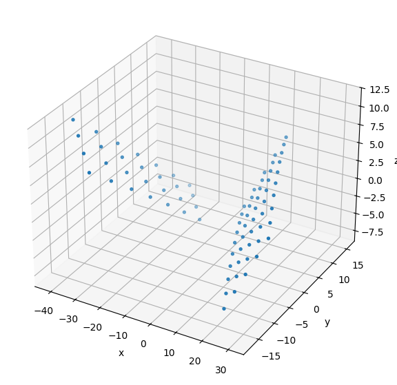

```python
def upgrade(Min, Xin):
    """
    Find a 3x3 matrix A that enforces square pixels and zero skew, and apply it
    to the affine reconstruction.

    input:
        Min: 2m x 3 torch tensor of camera rows, from affine_factorization
        Xin: n x 3  torch tensor of world points, from affine_factorization
    output:
        Mout, Xout: the upgraded cameras and points, as numpy arrays
    """
    # inputs
    Min = Min.detach().to(dtype=torch.float64)
    Xin = Xin.detach().to(device=Min.device, dtype=torch.float64) # keep the points and cameras on the same CPU

    m = Min.shape[0] // 2

    # adjustable parameters
    B = torch.zeros(
        (3, 3),
        dtype=Min.dtype,
        device=Min.device,
        requires_grad=True  # Pytorch calculates the loss changes when B changes
    )

    I = torch.eye(3, dtype=Min.dtype, device=Min.device) # identity matrix
    optimizer = torch.optim.Adam([B], lr=0.01) # use PyTorch Adam to adjust B using gradients

    # normalize loss
    loss_scale = (
        m * torch.mean(torch.sum(Min**2, dim=1))**2
    ).clamp_min(1e-12)

    for step in range(3000):
      optimizer.zero_grad()

      # construct A with scale-fixed correction
      H = (B + B.T) / 2
      H = H - torch.trace(H) / 3 * I
      A = torch.matrix_exp(H)

      M_candidate = Min @ A

      loss = torch.zeros(
          (), dtype=Min.dtype, device=Min.device
      )

      for i in range(m):
        r1 = M_candidate[2*i, :]
        r2 = M_candidate[2*i + 1, :]

        # zero skew
        dot_product = torch.sum(r1 * r2) # penalize rows that are not perpendicular

        # square pixels
        length_difference = (
            torch.sum(r1**2) - torch.sum(r2**2) # penalize unequal squared row lengths
        )

        loss = loss + dot_product**2 + length_difference**2 # prevents positive and negative violations from cancelling

      normalized_loss = loss / loss_scale

      normalized_loss.backward() # scale by the denominator
      optimizer.step() # update parameters

    with torch.no_grad():
      H = (B + B.T) / 2
      H = H - torch.trace(H) / 3 * I
      A = torch.matrix_exp(H)

      Mout = Min @ A
      Xout = torch.linalg.solve(A, Xin.T).T

    return Mout.cpu().numpy(), Xout.cpu().numpy()


Mout, Xout = upgrade(torch.tensor(M), torch.tensor(X))

print("E_rms before upgrade = {:.4f} pixels".format(calc_RMS(corners, M, X, T)))
print("E_rms after  upgrade = {:.4f} pixels".format(calc_RMS(corners, Mout, Xout, T)))

plot_interactive_3d(Xout)
plot_3d(Xout)
```

### Answer:

I initially expected the metric upgrade to reduce the RMS reprojection error, but the error remained 11.8408. This result means that the upgraded transform changes the cameras and 3D points in parallel. Which perserves their predicted pixel coordinates. The 3D plots differ in shape and proportions with no skew and zero squared pixels while keeping the same reprojection error.

# Question 2 (60%)

The assignment's data folder contains 24 pinhole images of a playroom scene (`playroom_#####.png`). The camera's intrinsic parameters are the same for all images,

$$ {\bf K}=\begin{bmatrix} 764.04 & 0 & 381.50 \\ 0 & 764.04 & 498.90 \\ 0 & 0 & 1 \end{bmatrix}, $$

and there is no optical distortion.

## 2a. Implement a sequential structure-from-motion pipeline

Your task is to implement a sequential structure-from-motion pipeline according to the steps we learned in Meeting M7. A copy of the relevant slide is included here.

[figure not shown]

Note that the two bundle adjustment steps are optional and should be attempted only when you have already succeeded in: (i) reconstructing a base pair and (ii) adding at least one additional camera in the iterative phase.

We expect you to make substantial use of the structure-from-motion functions that already exist in OpenCV. To get you started, we provide some starter code in the following cell, which detects and matches SIFT features between two of the images and recovers their relative pose. The `add_plotly_camera` and `make_visualization` helpers defined in the setup section and demonstrated in Hints and Information will draw your reconstruction once you have one.

This question is open-ended, and there are many ways to succeed. You will have the opportunity to share a visualization of your reconstruction with the class at the end of the week, and we look forward to seeing what you create!

```
8752 of 34670 matches survive the ratio test
4756 survive the fundamental-matrix RANSAC
```

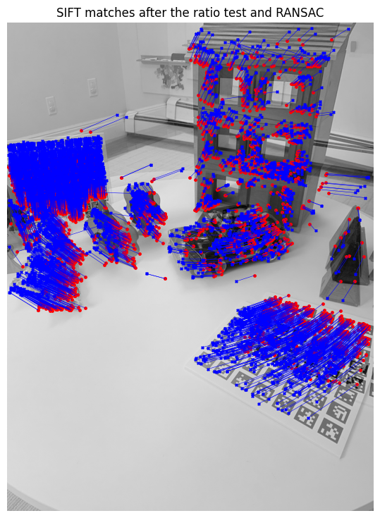

```
Rotation Matrix (R):
[[ 0.98723395 -0.10387769  0.12074167]
 [ 0.10771414  0.99385029 -0.0256762 ]
 [-0.11733196  0.038354    0.99235184]]

Translation Vector (t):
[[-0.97555771]
 [ 0.12442855]
 [-0.18112067]]
```

```python
# Starter code: match two images and recover their relative pose.
# You are free to change any of this.

# Load images
im1 = cv2.imread('data/playroom_00005.png', cv2.IMREAD_GRAYSCALE)
im2 = cv2.imread('data/playroom_00006.png', cv2.IMREAD_GRAYSCALE)
h, w = im1.shape

# Load intrinsic matrix K
K = np.array([[764.04, 0, 381.50],
              [0, 764.04, 498.90],
              [0, 0, 1]])

# Initialize SIFT detector
sift = cv2.SIFT_create(nOctaveLayers=10, contrastThreshold=0.01, edgeThreshold=15, sigma=1.2)

# Find key points and descriptors for the first two images
keypoints1, descriptors1 = sift.detectAndCompute(im1, None)
keypoints2, descriptors2 = sift.detectAndCompute(im2, None)

# FLANN-based descriptor matcher
matcher = cv2.FlannBasedMatcher()

# Match descriptors using KNN
matches = matcher.knnMatch(descriptors1, descriptors2, k=2)

# Apply Lowe's ratio test to filter good matches.  A descriptor is kept only if
# its best match is clearly better than its second-best; 0.7-0.8 is the usual
# range.  Raising this towards 1.0 keeps nearly everything and leaves RANSAC to
# do all the work, which is slower and gives a worse model.
ratio = 0.8
good_matches = []
for m, n in matches:
    if m.distance < ratio * n.distance:
        good_matches.append(m)
print(f"{len(good_matches)} of {len(matches)} matches survive the ratio test")

# Get matched key points
points1 = np.float32([keypoints1[m.queryIdx].pt for m in good_matches]).reshape(-1, 2)
points2 = np.float32([keypoints2[m.trainIdx].pt for m in good_matches]).reshape(-1, 2)

# Use RANSAC on the fundamental matrix to drop the remaining bad correspondences
confidence = 0.999
ransacReprojThreshold = 0.5
maxIters = 2000
_, inlier_mask = cv2.findFundamentalMat(
    points1, points2, cv2.FM_RANSAC,
    ransacReprojThreshold=ransacReprojThreshold,
    confidence=confidence,
    maxIters=maxIters
)
points1_Ffiltered = points1[inlier_mask.ravel() == 1]
points2_Ffiltered = points2[inlier_mask.ravel() == 1]
print(f"{len(points1_Ffiltered)} survive the fundamental-matrix RANSAC")

fig, ax = plt.subplots(figsize=(7, 9))
ax.imshow(im1, cmap='gray')
ax.scatter(points1_Ffiltered[:, 0], points1_Ffiltered[:, 1], c='red', marker='o', s=6)
for i in range(len(points1_Ffiltered)):
    ax.plot([points1_Ffiltered[i, 0], points2_Ffiltered[i, 0]],
            [points1_Ffiltered[i, 1], points2_Ffiltered[i, 1]], 'blue', linewidth=0.4)
ax.imshow(im2, alpha=0.5, cmap='gray')
ax.scatter(points2_Ffiltered[:, 0], points2_Ffiltered[:, 1], c='blue', marker='x', s=6)
ax.axis('off')
ax.set_title("SIFT matches after the ratio test and RANSAC")
plt.savefig("matches.png", bbox_inches='tight')
plt.show()

# Use RANSAC to estimate the essential matrix
E, _ = cv2.findEssentialMat(points1_Ffiltered, points2_Ffiltered, K,
                            method=cv2.RANSAC, prob=0.99, threshold=1.0)

# Recover relative pose (R, t) from the essential matrix
_, R, t, _ = cv2.recoverPose(E, points1_Ffiltered, points2_Ffiltered, K)

print("\nRotation Matrix (R):")
print(R)
print("\nTranslation Vector (t):")
print(t)
```

**Step 1: reconstruct the base pair.** Triangulate the surviving matches from the starter code to get an initial set of 3D points, and store the two cameras and their points in a dictionary so that later steps can look them up. The rest of this question assumes the keys `P_<i>` (3x4 camera), `2d_<i>` (n x 2 image points), `3d_<i>` (n x 3 world points) and `3d_comple_<i>` (the points to plot), where `<i>` is the image number.

```python
camera_dic = {}          # placeholder result, replaced by your code below

# Build the two camera matrices
P1 = K @ np.hstack((np.eye(3), np.zeros((3, 1))))
P2 = K @ np.hstack((R, t))

# Triangulate the surviving 2D matches
points4D_h = cv2.triangulatePoints(
    P1,
    P2,
    points1_Ffiltered.T,
    points2_Ffiltered.T
)

# Convert homogeneous 3D points to inhomogeneous coordinates
points3D = (points4D_h[:3, :] / points4D_h[3, :]).T

# Keep only points that are in front of both cameras
points_cam1 = points3D
points_cam2 = (R @ points3D.T + t).T

valid = (points_cam1[:, 2] > 0) & (points_cam2[:, 2] > 0)

points3D_valid = points3D[valid]
points1_valid = points1_Ffiltered[valid]
points2_valid = points2_Ffiltered[valid]

# Store cameras, 2D points, and corresponding 3D points
camera_dic['P_5'] = P1
camera_dic['P_6'] = P2

camera_dic['2d_5'] = points1_valid
camera_dic['2d_6'] = points2_valid

camera_dic['3d_5'] = points3D_valid
camera_dic['3d_6'] = points3D_valid

# Store one copy for plotting so the same points are not plotted twice
camera_dic['3d_comple_5'] = points3D_valid
camera_dic['3d_comple_6'] = np.empty((0, 3))

print("Number of triangulated 3D points:", len(points3D_valid))
```

```
Number of triangulated 3D points: 4755
```

**Step 2: add more cameras.** Repeatedly pick an image you have already reconstructed, match it against one you have not, solve the perspective-n-point problem to place the new camera, and triangulate the matches that are new. Add as many of the 24 images as you can.

```python
def add_camera(ref_idx, new_idx, camera_dic, K):
    # Load the two images
    im_ref = cv2.imread(f"data/playroom_{ref_idx:05d}.png", cv2.IMREAD_GRAYSCALE)
    im_new = cv2.imread(f"data/playroom_{new_idx:05d}.png", cv2.IMREAD_GRAYSCALE)

    # Detect SIFT features
    kp_ref, des_ref = sift.detectAndCompute(im_ref, None)
    kp_new, des_new = sift.detectAndCompute(im_new, None)

    # Match descriptors
    matches = matcher.knnMatch(des_ref, des_new, k=2)

    good_matches = []
    for m, n in matches:
        if m.distance < ratio * n.distance:
            good_matches.append(m)

    if len(good_matches) < 8:
        print(f"{ref_idx} -> {new_idx}: not enough matches")
        return False

    pts_ref = np.float32(
        [kp_ref[m.queryIdx].pt for m in good_matches]
    ).reshape(-1, 2)

    pts_new = np.float32(
        [kp_new[m.trainIdx].pt for m in good_matches]
    ).reshape(-1, 2)

    # Fundamental-matrix RANSAC to clean the matches
    F, mask = cv2.findFundamentalMat(
        pts_ref,
        pts_new,
        cv2.FM_RANSAC,
        ransacReprojThreshold=0.5,
        confidence=0.999,
        maxIters=2000
    )

    if F is None or mask is None:
        print(f"{ref_idx} -> {new_idx}: fundamental matrix failed")
        return False

    pts_ref = pts_ref[mask.ravel() == 1]
    pts_new = pts_new[mask.ravel() == 1]

    # Existing 2D <-> 3D correspondences in the reference image
    old_2d = camera_dic[f"2d_{ref_idx}"]
    old_3d = camera_dic[f"3d_{ref_idx}"]

    pnp_2d = []
    pnp_3d = []

    new_ref_pts = []
    new_img_pts = []

    # Decide which matches already correspond to known 3D points
    for p_ref, p_new in zip(pts_ref, pts_new):

        distances = np.linalg.norm(old_2d - p_ref, axis=1)
        nearest = np.argmin(distances)

        if distances[nearest] < 2.0:
            # This feature already has a known 3D point
            pnp_2d.append(p_new)
            pnp_3d.append(old_3d[nearest])

        else:
            # This feature has not yet been reconstructed
            new_ref_pts.append(p_ref)
            new_img_pts.append(p_new)

    pnp_2d = np.asarray(pnp_2d, dtype=np.float32)
    pnp_3d = np.asarray(pnp_3d, dtype=np.float32)

    if len(pnp_3d) < 6:
        print(f"{ref_idx} -> {new_idx}: only {len(pnp_3d)} usable 3D-2D matches")
        return False

    # PnP: known 3D points + their positions in the new image -> new camera pose
    success, rvec, tvec, pnp_inliers = cv2.solvePnPRansac(
        pnp_3d,
        pnp_2d,
        K,
        None,
        iterationsCount=500,
        reprojectionError=4.0,
        confidence=0.999,
        flags=cv2.SOLVEPNP_ITERATIVE
    )

    if not success:
        print(f"{ref_idx} -> {new_idx}: PnP failed")
        return False

    R_new, _ = cv2.Rodrigues(rvec)

    P_new = K @ np.hstack((R_new, tvec))

    # Keep only the known correspondences accepted by PnP
    pnp_inliers = pnp_inliers.ravel()

    known_2d_new = pnp_2d[pnp_inliers]
    known_3d_new = pnp_3d[pnp_inliers]

    # Triangulate the matches that do NOT already have 3D points
    new_ref_pts = np.asarray(new_ref_pts, dtype=np.float32)
    new_img_pts = np.asarray(new_img_pts, dtype=np.float32)

    new_points_3d = np.empty((0, 3))

    if len(new_ref_pts) > 0:

        P_ref = camera_dic[f"P_{ref_idx}"]

        X_h = cv2.triangulatePoints(
            P_ref,
            P_new,
            new_ref_pts.T,
            new_img_pts.T
        )

        X = (X_h[:3, :] / X_h[3, :]).T

        # Recover extrinsics of reference camera
        Rt_ref = np.linalg.inv(K) @ P_ref
        R_ref = Rt_ref[:, :3]
        t_ref = Rt_ref[:, 3:4]

        # Check that triangulated points are in front of both cameras
        X_ref = (R_ref @ X.T + t_ref).T
        X_new = (R_new @ X.T + tvec).T

        valid = (
            np.isfinite(X).all(axis=1)
            & (X_ref[:, 2] > 0)
            & (X_new[:, 2] > 0)
        )

        new_points_3d = X[valid]
        new_img_pts = new_img_pts[valid]

    # Store everything for this new camera
    camera_dic[f"P_{new_idx}"] = P_new

    # Known old points seen by new camera + newly triangulated points
    camera_dic[f"2d_{new_idx}"] = np.vstack(
        (known_2d_new, new_img_pts)
    )

    camera_dic[f"3d_{new_idx}"] = np.vstack(
        (known_3d_new, new_points_3d)
    )

    # Only store genuinely NEW points here so visualization does not duplicate them
    camera_dic[f"3d_comple_{new_idx}"] = new_points_3d

    print(
        f"{ref_idx} -> {new_idx}: "
        f"{len(known_3d_new)} PnP inliers, "
        f"{len(new_points_3d)} new 3D points"
    )

    return True


# Grow reconstruction forward from image 6
for new_idx in range(7, 25):
    ref_idx = new_idx - 1

    if f"P_{ref_idx}" in camera_dic:
        add_camera(ref_idx, new_idx, camera_dic, K)


# Grow reconstruction backward from image 5
for new_idx in range(4, 0, -1):
    ref_idx = new_idx + 1

    if f"P_{ref_idx}" in camera_dic:
        add_camera(ref_idx, new_idx, camera_dic, K)
```

```
6 -> 7: 3144 PnP inliers, 3026 new 3D points
7 -> 8: 3538 PnP inliers, 1959 new 3D points
8 -> 9: 3590 PnP inliers, 2502 new 3D points
9 -> 10: 2233 PnP inliers, 1595 new 3D points
10 -> 11: 1950 PnP inliers, 2854 new 3D points
11 -> 12: 1884 PnP inliers, 2094 new 3D points
12 -> 13: 877 PnP inliers, 1772 new 3D points
13 -> 14: 613 PnP inliers, 1070 new 3D points
14 -> 15: 571 PnP inliers, 1369 new 3D points
15 -> 16: 888 PnP inliers, 1992 new 3D points
16 -> 17: 1020 PnP inliers, 1871 new 3D points
17 -> 18: 1521 PnP inliers, 2246 new 3D points
18 -> 19: 2475 PnP inliers, 2426 new 3D points
19 -> 20: 2052 PnP inliers, 982 new 3D points
20 -> 21: 1027 PnP inliers, 776 new 3D points
21 -> 22: 1087 PnP inliers, 5338 new 3D points
22 -> 23: 2849 PnP inliers, 2720 new 3D points
23 -> 24: 2434 PnP inliers, 5763 new 3D points
5 -> 4: 2292 PnP inliers, 2068 new 3D points
4 -> 3: 2771 PnP inliers, 2316 new 3D points
3 -> 2: 2755 PnP inliers, 1994 new 3D points
2 -> 1: 2647 PnP inliers, 2715 new 3D points
```

```python
# GLOBAL BUNDLE ADJUSTMENT

import copy
from scipy.optimize import least_squares
from scipy.sparse import lil_matrix

# Keep a copy of the reconstruction before bundle adjustment

camera_dic_before_ba = copy.deepcopy(camera_dic)

# Helper: force a nearly-rotation matrix to be a true rotation

def nearest_rotation(R):
    U, _, Vt = np.linalg.svd(R)
    R_corrected = U @ Vt

    if np.linalg.det(R_corrected) < 0:
        U[:, -1] *= -1
        R_corrected = U @ Vt

    return R_corrected

# Find all reconstructed cameras

camera_ids = sorted([
    int(key.split('_')[1])
    for key in camera_dic
    if key.startswith('P_')
])

print("Cameras before bundle adjustment:", camera_ids)

# Extract initial R,t for each camera

camera_params_initial = {}

K_inv = np.linalg.inv(K)

for cam_id in camera_ids:

    P = camera_dic[f'P_{cam_id}']

    # P = K [R | t]
    Rt = K_inv @ P

    R = Rt[:, :3]
    t = Rt[:, 3]

    R = nearest_rotation(R)

    rvec, _ = cv2.Rodrigues(R)

    camera_params_initial[cam_id] = np.hstack(
        (rvec.ravel(), t.ravel())
    )

# Build a shared list of 3D points and observations

def point_key(X):
    return tuple(np.round(X, decimals=6))

point_coordinates = {}
point_observations = {}

for cam_id in camera_ids:

    key2d = f'2d_{cam_id}'
    key3d = f'3d_{cam_id}'

    if key2d not in camera_dic or key3d not in camera_dic:
        continue

    pts2d = camera_dic[key2d]
    pts3d = camera_dic[key3d]

    for xy, X in zip(pts2d, pts3d):

        if not np.all(np.isfinite(X)):
            continue

        key = point_key(X)

        if key not in point_coordinates:
            point_coordinates[key] = np.array(X, dtype=float)
            point_observations[key] = []

        point_observations[key].append(
            (cam_id, np.array(xy, dtype=float))
        )

# Only use points seen in at least two cameras

valid_point_keys = [
    key
    for key in point_coordinates
    if len(point_observations[key]) >= 2
]

print("Unique reconstructed points:",
      len(point_coordinates))

print("Points seen in >= 2 cameras:",
      len(valid_point_keys))

point_index = {
    key: i
    for i, key in enumerate(valid_point_keys)
}

# Fix the base pair to remove gauge ambiguity

fixed_cameras = {5, 6}

variable_camera_ids = [
    cam_id
    for cam_id in camera_ids
    if cam_id not in fixed_cameras
]

camera_index = {
    cam_id: i
    for i, cam_id in enumerate(variable_camera_ids)
}

# Pack parameters into one vector
# First: 6 parameters per variable camera
# [rx, ry, rz, tx, ty, tz]
# Then: 3 parameters per 3D point
# [X, Y, Z]

x0_parts = []

for cam_id in variable_camera_ids:
    x0_parts.append(camera_params_initial[cam_id])

for key in valid_point_keys:
    x0_parts.append(point_coordinates[key])

x0 = np.concatenate(x0_parts)

num_camera_params = 6 * len(variable_camera_ids)

point_start = num_camera_params

# Build observation arrays

obs_camera_ids = []
obs_point_ids = []
obs_xy = []

for key in valid_point_keys:

    pid = point_index[key]

    for cam_id, xy in point_observations[key]:

        obs_camera_ids.append(cam_id)
        obs_point_ids.append(pid)
        obs_xy.append(xy)

obs_camera_ids = np.array(obs_camera_ids)
obs_point_ids = np.array(obs_point_ids)
obs_xy = np.array(obs_xy)

print("Total 2D observations used:",
      len(obs_xy))

# Helper to retrieve camera parameters

def get_camera_parameters(params, cam_id):

    if cam_id in fixed_cameras:

        camera_params = camera_params_initial[cam_id]

    else:

        idx = camera_index[cam_id]

        start = 6 * idx
        end = start + 6

        camera_params = params[start:end]

    rvec = camera_params[:3]
    t = camera_params[3:]

    R, _ = cv2.Rodrigues(rvec)

    return R, t

# Faster bundle-adjustment residual function

def bundle_residuals(params):

    points = params[point_start:].reshape(-1, 3)

    residuals = np.zeros((len(obs_xy), 2))

    for cam_id in camera_ids:

        mask = (obs_camera_ids == cam_id)

        if not np.any(mask):
            continue

        R, t = get_camera_parameters(params, cam_id)

        X = points[obs_point_ids[mask]]

        # World -> camera coordinates
        X_camera = (R @ X.T).T + t

        # Camera -> homogeneous image coordinates
        x_h = (K @ X_camera.T).T

        # Avoid division by zero
        z = x_h[:, 2].copy()
        z[np.abs(z) < 1e-10] = 1e-10

        # Homogeneous -> pixel coordinates
        projected_xy = x_h[:, :2] / z[:, None]

        # Reprojection residual
        residuals[mask] = projected_xy - obs_xy[mask]

    return residuals.ravel()

# Sparse Jacobian structure

num_observations = len(obs_xy)
num_parameters = len(x0)

A = lil_matrix(
    (2 * num_observations, num_parameters),
    dtype=int
)

for i, (cam_id, pid) in enumerate(
    zip(obs_camera_ids, obs_point_ids)
):

    # Observation depends on its camera
    if cam_id not in fixed_cameras:

        cam_pos = camera_index[cam_id]

        cam_start = 6 * cam_pos

        A[2*i:2*i+2,
          cam_start:cam_start+6] = 1

    # Observation depends on its 3D point
    pt_start = point_start + 3 * pid

    A[2*i:2*i+2,
      pt_start:pt_start+3] = 1

# Print problem size

print("Variable cameras:",
      len(variable_camera_ids))

print("3D points being optimized:",
      len(valid_point_keys))

print("2D observations:",
      len(obs_xy))

print("Total optimization parameters:",
      len(x0))

# Error before optimization

initial_residuals = bundle_residuals(x0)

initial_rmse = np.sqrt(
    np.mean(initial_residuals**2)
)

print("Initial reprojection RMSE:",
      initial_rmse)

# Run bundle adjustment

result = least_squares(
    bundle_residuals,
    x0,
    jac_sparsity=A,
    verbose=2,
    x_scale='jac',
    loss='soft_l1',
    f_scale=2.0,
    max_nfev=30
)

# Error after optimization

final_residuals = bundle_residuals(result.x)

final_rmse = np.sqrt(
    np.mean(final_residuals**2)
)

print("Final reprojection RMSE:",
      final_rmse)

# Extract optimized points

optimized_points = result.x[
    point_start:
].reshape(-1, 3)

optimized_point_lookup = {}

for key, pid in point_index.items():
    optimized_point_lookup[key] = optimized_points[pid]

# Update camera matrices

for cam_id in variable_camera_ids:

    idx = camera_index[cam_id]

    params = result.x[
        6*idx : 6*idx + 6
    ]

    rvec = params[:3]
    t = params[3:].reshape(3, 1)

    R, _ = cv2.Rodrigues(rvec)

    camera_dic[f'P_{cam_id}'] = (
        K @ np.hstack((R, t))
    )

# Update 3D coordinates in camera_dic

for key in list(camera_dic.keys()):

    if (
        key.startswith('3d_')
        and not key.startswith('3d_comple_')
    ):

        pts = camera_dic[key].copy()

        for i in range(len(pts)):

            k = point_key(pts[i])

            if k in optimized_point_lookup:
                pts[i] = optimized_point_lookup[k]

        camera_dic[key] = pts

for key in list(camera_dic.keys()):

    if key.startswith('3d_comple_'):

        pts = camera_dic[key].copy()

        for i in range(len(pts)):

            k = point_key(pts[i])

            if k in optimized_point_lookup:
                pts[i] = optimized_point_lookup[k]

        camera_dic[key] = pts

print("Bundle adjustment complete.")
```

[output not shown]

**Step 3: visualize.** Run the following cell to plot your reconstructed points and cameras and export them to standalone file `reconstruction.html`. (See the [plotly docs](https://plotly.com/python/interactive-html-export/) for more on standalone HTML export.)

```python
make_visualization(camera_dic, h, w, filename="reconstruction.html")
```

## 2b. Finalize your visualization

To improve aesthetics, filter out the background points that are very far from the cameras or that are distracting (e.g., with a large $z$ coordinate). Then create another visualization and file export `reconstruction_filtered.html`.

```python
# Make a copy so the original reconstruction is unchanged
filtered = camera_dic.copy()

# Collect all reconstructed 3D points
all_points = []

for key in camera_dic:
    if key.startswith('3d_comple_'):
        pts = camera_dic[key]

        if len(pts) > 0:
            all_points.append(pts)

all_points = np.vstack(all_points)

# Find the camera centers

camera_centers = []

for key in camera_dic:
    if key.startswith('P_'):
        P = camera_dic[key]

        _, _, Vt = np.linalg.svd(P)

        C_h = Vt[-1]
        C = C_h[:3] / C_h[3]

        camera_centers.append(C)

camera_centers = np.array(camera_centers)

# Determine reasonable limits from the reconstruction itself

# Distance of every point to its nearest camera
distances = np.linalg.norm(
    all_points[:, None, :] - camera_centers[None, :, :],
    axis=2
)

nearest_camera_distance = np.min(distances, axis=1)

# Remove the most extreme distant points
distance_limit = np.percentile(nearest_camera_distance, 98)

# Also remove extreme z-coordinate outliers
z_min = np.percentile(all_points[:, 2], 1)
z_max = np.percentile(all_points[:, 2], 98)

# Filter each set of newly reconstructed points

total_before = 0
total_after = 0

for key in camera_dic:

    if key.startswith('3d_comple_'):

        pts = camera_dic[key]

        if len(pts) == 0:
            continue

        total_before += len(pts)

        # Distance from each point to every camera
        d = np.linalg.norm(
            pts[:, None, :] - camera_centers[None, :, :],
            axis=2
        )

        nearest_d = np.min(d, axis=1)

        valid = (
            np.isfinite(pts).all(axis=1)
            & (nearest_d < distance_limit)
            & (pts[:, 2] > z_min)
            & (pts[:, 2] < z_max)
        )

        filtered[key] = pts[valid]

        total_after += np.sum(valid)

print("Points before filtering:", total_before)
print("Points after filtering:", total_after)

make_visualization(filtered, h, w, filename="reconstruction_filtered.html")
```

[output not shown]

# Hints and Information

### Visualizing cameras in 3D

Two helpers are defined for you in the *utility functions* cell of the setup section:

- `add_plotly_camera(h, w, camera, raysize, figobj)` draws a single $3\times4$ camera matrix as a tetrahedron, with its apex at the camera centre.
- `make_visualization(camera_dic, h, w, filename=...)` draws every point and camera in your dictionary, writes the figure to a standalone HTML file, and displays it.

The cell below is a self-contained demonstration of `add_plotly_camera` on a toy scene: the eight corners of a unit cube seen by three cameras looking inward. It uses its own `h_demo`, `w_demo` and `K_demo` so that running it does not disturb the `h`, `w` and `K` belonging to the playroom images in Question 2.

```python
# Toy demonstration of add_plotly_camera -- safe to run at any time.

# 3D points on a unit cube
points3D_demo = np.array([[0, 0, 0], [0, 1, 0], [1, 0, 0], [1, 1, 0],
                          [0, 0, 1], [0, 1, 1], [1, 0, 1], [1, 1, 1]])

# image height and width, and intrinsic parameters, for the toy cameras
h_demo, w_demo = 480, 640
K_demo = np.array([[300, 0, 320],
                   [0, 300, 240],
                   [0, 0, 1]])

# three cameras looking inward
camera_matrices_demo = [
    K_demo @ cv2.Rodrigues(np.array([0, 0, np.pi]))[0]
           @ np.hstack((np.eye(3), np.array([0, 0, 5]).reshape(3, 1))),
    K_demo @ cv2.Rodrigues(np.array([np.pi/2, 0, 0]))[0]
           @ np.hstack((np.eye(3), np.array([0, 5, 0]).reshape(3, 1))),
    K_demo @ cv2.Rodrigues(np.array([0, -np.pi/2, 0]))[0]
           @ np.hstack((np.eye(3), np.array([5, 0, 0]).reshape(3, 1))),
]

fig_demo = go.Figure()
fig_demo.add_trace(go.Scatter3d(
    x=points3D_demo[:, 0], y=points3D_demo[:, 1], z=points3D_demo[:, 2],
    mode='markers', marker=dict(size=2)))

for cam in camera_matrices_demo:
    add_plotly_camera(h_demo, w_demo, cam, 1, fig_demo)

fig_demo.update_traces(showlegend=False)
fig_demo.update_layout(scene_dragmode='orbit', scene=dict(aspectmode='data'))
fig_demo.show()
```

# Submission

The cells below generate two files in the folder `cs-283-assignments/A4/submit` on your Google Drive:

1. `LASTNAME_FIRSTNAME_pset4.html`: an HTML report of your notebook **[Submit to GradeScope, after converting to PDF format]**
2. `LASTNAME_FIRSTNAME_pset4.zip`: a `.zip` file including `pset4.ipynb` and the figures and HTML visualizations you generated **[Submit to Canvas]**

**Remember to edit the filenames (either in the cells below or on your local computer after downloading) to match your name, and make sure to save your notebook before running the cells.**

This assignment produces interactive plotly figures, which cannot be embedded in the PDF. That is why Question 1 asks for a matplotlib plot alongside every plotly one, and why Question 2b asks you to export your reconstruction to a standalone HTML file — make sure that file is in the zip you submit to Canvas. Those HTML files load plotly.js from the web, so open them with an internet connection.

The zip does **not** include the `data` folder. Everything in it is downloaded by the setup cell at the top of this notebook and is already available to the graders, and including it would add more than 80 MB to every submission.

Each teammate submits their own copy of the notebook, along with their own supplemental PDF describing each of your contributions.

```python
!mkdir "submit"
```

```python
# Convert to HTML - don't forget to add your name
# Make sure to save your notebook before running the following
!jupyter nbconvert --to html pset4.ipynb --output-dir "submit" --output "SARAN_RADHIKA_BLAIR_JOSHUA_pset4.html"
```

```python
from zipfile import ZipFile

def writeFolder(zip, path):
  import os
  for dirpath,dirs,files in os.walk(path):
    for f in files:
      fn = os.path.join(dirpath, f)
      zip.write(fn)

def writeFile(zip, path):
  zip.write(path)
```

```python
# Zip source - don't forget to add your name
zipObj = ZipFile('submit/SARAN_RADHIKA_BLAIR_JOSHUA_pset4.zip', 'w')

# NB: the data folder is deliberately not included -- see the note above.
writeFile(zipObj, "pset4.ipynb")

# include the figures and visualizations produced above
for extra in ['matches.png', 'reconstruction.html', 'reconstruction_filtered.html']:
  if os.path.exists(extra):
    writeFile(zipObj, extra)

zipObj.close()
print("wrote submit/SARAN_RADHIKA_BLAIR_JOSHUA_pset4.zip")
```